[figure not shown]

# Makroökonomik II: Zusätzliches Material

Sommer Semester 2022

by Markus Mößler

# Wohlstand Beschreiben

*Dieses Dokument enthält ausgewählter Zeitreihen zur Analyse von Wohlstand.*

## Einführung

Einordnung

Für die Einordnung siehe auch Kapitel 2.2 “Vermessung von Wohlstand.”

- Zielgröße: Wohlstand
  - BIP
  - Alternative Wohlstandsmaße?
- Variablen zur Analyse von Wohlstand
  - Inflationsrate:
    - AD-AS-Modell (statisch & dynamisch)
  - Zinsen:
    - Mittlere Frist (kleine/große & geschlossene/offene Volkswirtschaft)
    - IS-LM Modell (kleine/große & geschlossene Volkswirtschaft)
    - Mundell-Flemming Modell (große & offene Volkswirtschaft)
  - Wechselkurse:
    - Mittlere Frist (kleine/große & offene Volkswirtschaft)
    - Mundell-Flemming Modell (kleine/große & offene Volkswirtschaft)

Vorbereitung

Die Daten werden von unterschiedlichen öffentlich zugägnlichen Datenbanken herunterledadn.

Die Daten können entweder auf der Webseite oder über so genannte Programmierschnittstellen (APIs) hetuntergeladen werden.

### FRED

FRED

- Webseite: ([siehe](https://fred.stlouisfed.org/))
- R-Software: Paket `fredr` (siehe unten)

```r
# setwd("... insert-you-directory-here ...")
```

```r
library(dplyr)
library(tidyr)
library(ggplot2)
library(readxl)
library(scales)
# see: https://stackoverflow.com/questions/11610377/how-do-i-change-the-formatting-of-numbers-on-an-axis-with-ggplot
library(zoo)
```

```r
# FRED
library(fredr)
# fredr_set_key("... insert-your-personal-key-here ...")
```

```r
# See: https://rpubs.com/FSl/609471
add_rec_shade <- function(st_date,ed_date,shade_color="darkgray",zoo.mon=FALSE,zoo.qtr=FALSE) {

  library(fredr)
  library(ecm)
  library(ggplot2)
  library(zoo)
  #fredr_set_key("insert_your_api_key")

  #st_date<-as.Date("2001-06-01")
  #ed_date<-as.Date(Sys.Date())

  recession <- fredr(series_id = "USRECD",observation_start = as.Date(st_date),observation_end = as.Date(ed_date))

  recession$diff <- recession$value-lagpad(recession$value,k=1)
  recession <- recession[!is.na(recession$diff),]
  recession.start <- recession[recession$diff==1,]$date
  recession.end <- recession[recession$diff==(-1),]$date

  if(length(recession.start)>length(recession.end)){
    recession.end <-c (recession.end,Sys.Date())
  }
  if(length(recession.end)>length(recession.start)){
    recession.start <- c(min(recession$date),recession.start)
  }

  recs <- as.data.frame(cbind(recession.start,recession.end))
  recs$recession.start <- as.Date(as.numeric(recs$recession.start),origin=as.Date("1970-01-01"))
  if(zoo.mon==TRUE){
    recs$recession.start <- as.yearmon(recs$recession.start,"%b%y")
  }
  if(zoo.qtr==TRUE){
    recs$recession.start <- as.yearqtr(recs$recession.start,"%y-Q%q")
  }

  recs$recession.end <- as.Date(recs$recession.end,origin=as.Date("1970-01-01"))
  if(zoo.mon==TRUE){
    recs$recession.end <- as.yearmon(recs$recession.end,"%b%y")
  }
  if(zoo.qtr==TRUE){
    recs$recession.end <- as.yearqtr(recs$recession.end,"%y-Q%q")
  }

  if(nrow(recs)>0){
    rec_shade <- geom_rect(data=recs, inherit.aes=F,
                           aes(xmin=recession.start, xmax=recession.end, ymin=-Inf, ymax=+Inf),
                           fill=shade_color, alpha=0.5)
    return(rec_shade)
  }
}
```

Back To Start

### Eurostat and ECB

Eurostat and ECB

- Webseite:
  - ([Eurostat](https://ec.europa.eu/eurostat/de/home))
  - ([ECB](https://sdw.ecb.europa.eu))
- R-Software:
  - Paket `eurostat`
  - Paket `ecb`

```r
# eurostat
library(eurostat)
# ecb statistical data warehouse
library(ecb)
```

## Wohlstand

Wohlstand

### USA

USA

Real GDP (level)

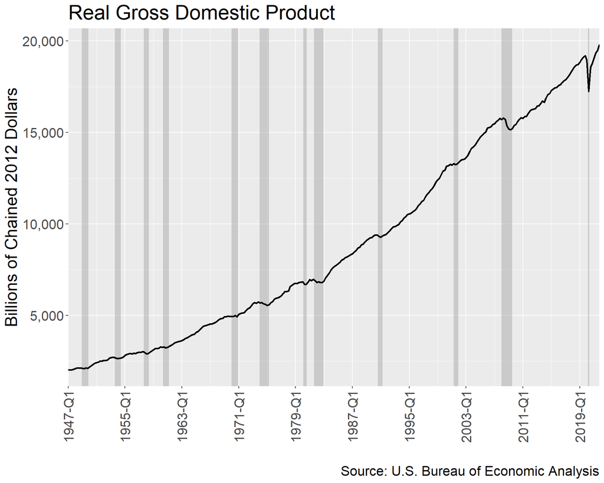

| Date | Period | Value |
| --- | --- | --- |
| 2019-07-01 | 2019 Q3 | 19112.65 |
| 2019-10-01 | 2019 Q4 | 19202.31 |
| 2020-01-01 | 2020 Q1 | 18951.99 |
| 2020-04-01 | 2020 Q2 | 17258.21 |
| 2020-07-01 | 2020 Q3 | 18560.77 |
| 2020-10-01 | 2020 Q4 | 18767.78 |
| 2021-01-01 | 2021 Q1 | 19055.65 |
| 2021-04-01 | 2021 Q2 | 19368.31 |
| 2021-07-01 | 2021 Q3 | 19478.89 |
| 2021-10-01 | 2021 Q4 | 19806.29 |

```r
# Meta data
met.dat <- fredr_series_search_text("GDPC1")
# Data
ser.dat <- fredr_series_observations(series_id=met.dat$id[1],
                                     observation_start=as.Date("1947-01-01"),
                                     units="lin")
# Transform date to yearmon class
ser.dat$date.zoo <- as.yearqtr(ser.dat$date,"%y-Q%q")
# Construct plot
gdp.01.plot <- ggplot(data=ser.dat,mapping=aes(x=date.zoo,y=value,color=series_id)) +
  add_rec_shade(min(ser.dat$date),max(ser.dat$date),zoo.mon=TRUE,zoo.qtr=FALSE) +
  geom_line(color = "black", size = 1) +
  scale_y_continuous(name="Billions of Chained 2012 Dollars",labels=comma) +
  scale_x_yearqtr(breaks=seq(from=min(ser.dat$date.zoo),to=max(ser.dat$date.zoo),by=8),
                  minor_breaks=seq(from=min(ser.dat$date.zoo),to=max(ser.dat$date.zoo),by=4),
                  format="%Y-Q%q",
                  expand = c(0, 0)) +
  labs(title = met.dat$title[1],
       caption = "Source: U.S. Bureau of Economic Analysis",
       x = "", y = "Billions of Chained 2012 Dollars") +
  theme(legend.position="none",
        axis.text.x = element_text(angle=90, vjust = 0.5),
        text = element_text(size = 20))
# Print plot
gdp.01.plot
```

Real GDP (perchentage change (YoY))

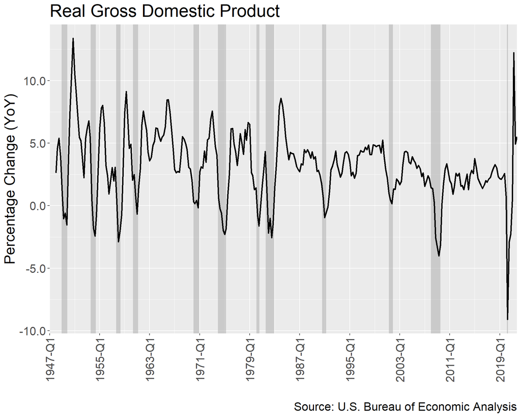

| Date | Period | Value |
| --- | --- | --- |
| 2019-07-01 | 2019 Q3 | 2.31833 |
| 2019-10-01 | 2019 Q4 | 2.56942 |
| 2020-01-01 | 2020 Q1 | 0.63079 |
| 2020-04-01 | 2020 Q2 | -9.08374 |
| 2020-07-01 | 2020 Q3 | -2.88751 |
| 2020-10-01 | 2020 Q4 | -2.26292 |
| 2021-01-01 | 2021 Q1 | 0.54698 |
| 2021-04-01 | 2021 Q2 | 12.22668 |
| 2021-07-01 | 2021 Q3 | 4.94656 |
| 2021-10-01 | 2021 Q4 | 5.53348 |

```r
# Meta data
met.dat <- fredr_series_search_text("GDPC1")
# Data
ser.dat <- fredr_series_observations(series_id=met.dat$id[1],
                                     observation_start=as.Date("1947-01-01"),
                                     units="pc1")
# Transform date to yearmon class
ser.dat$date.zoo <- as.yearqtr(ser.dat$date,"%y-Q%q")
# Construct plot
gdp.02.plot <- ggplot(data=ser.dat,mapping=aes(x=date.zoo,y=value,color=series_id)) +
  add_rec_shade(min(ser.dat$date),max(ser.dat$date),zoo.mon=TRUE,zoo.qtr=FALSE) +
  geom_line(color = "black", size = 1) +
  scale_y_continuous(name="Percentage Change (YoY)",labels=comma) +
  scale_x_yearqtr(breaks=seq(from=min(ser.dat$date.zoo),to=max(ser.dat$date.zoo),by=8),
                  minor_breaks=seq(from=min(ser.dat$date.zoo),to=max(ser.dat$date.zoo),by=4),
                  format="%Y-Q%q",
                  expand = c(0, 0)) +
  labs(title = met.dat$title[1],
       caption = "Source: U.S. Bureau of Economic Analysis",
       x = "", y = "Percentage Change (YoY)") +
  theme(legend.position="none",
        axis.text.x = element_text(angle=90, vjust = 0.5),
        text = element_text(size = 20))
# Print plot
gdp.02.plot
```

Real GDP (per capita)

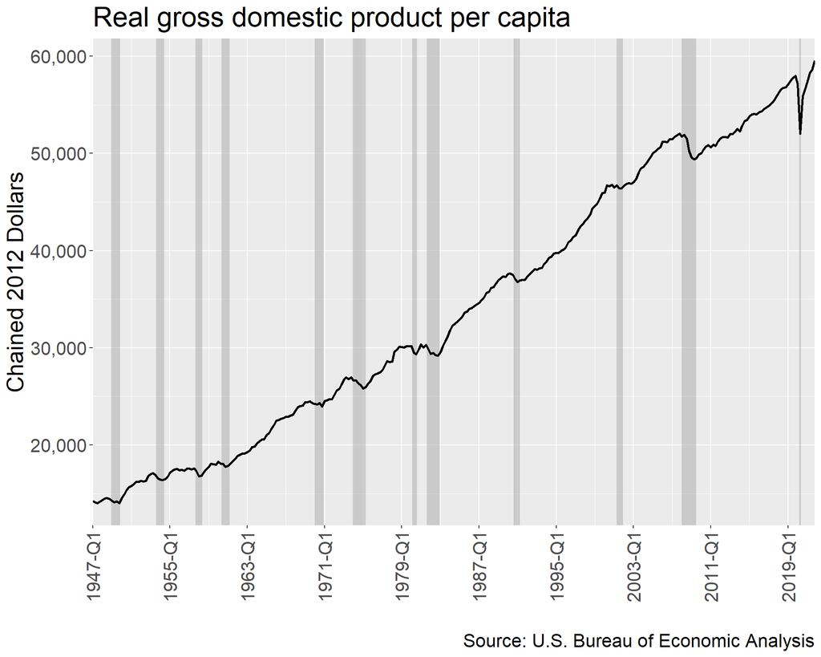

| Date | Period | Value |
| --- | --- | --- |
| 2019-07-01 | 2019 Q3 | 57789 |
| 2019-10-01 | 2019 Q4 | 57977 |
| 2020-01-01 | 2020 Q1 | 57165 |
| 2020-04-01 | 2020 Q2 | 52031 |
| 2020-07-01 | 2020 Q3 | 55933 |
| 2020-10-01 | 2020 Q4 | 56533 |
| 2021-01-01 | 2021 Q1 | 57405 |
| 2021-04-01 | 2021 Q2 | 58335 |
| 2021-07-01 | 2021 Q3 | 58619 |
| 2021-10-01 | 2021 Q4 | 59553 |

```r
# Meta data
met.dat <- fredr_series_search_text("A939RX0Q048SBEA")
# Data
ser.dat <- fredr_series_observations(series_id=met.dat$id[1],
                                     observation_start=as.Date("1947-01-01"),
                                     units="lin")
# Transform date to yearmon class
ser.dat$date.zoo <- as.yearqtr(ser.dat$date,"%y-Q%q")
# Construct plot
gdp.03.plot <- ggplot(data=ser.dat,mapping=aes(x=date.zoo,y=value,color=series_id)) +
  add_rec_shade(min(ser.dat$date),max(ser.dat$date),zoo.mon=TRUE,zoo.qtr=FALSE) +
  geom_line(color = "black", size = 1) +
  scale_y_continuous(name="Chained 2012 Dollars",labels=comma) +
  scale_x_yearqtr(breaks=seq(from=min(ser.dat$date.zoo),to=max(ser.dat$date.zoo),by=8),
                  minor_breaks=seq(from=min(ser.dat$date.zoo),to=max(ser.dat$date.zoo),by=4),
                  format="%Y-Q%q",
                  expand = c(0, 0)) +
  labs(title = met.dat$title[1],
       caption = "Source: U.S. Bureau of Economic Analysis",
       x = "", y = "Chained 2012 Dollars") +
  theme(legend.position="none",
        axis.text.x = element_text(angle=90, vjust = 0.5),
        text = element_text(size = 20))
# Print plot
gdp.03.plot
```

Back To Start

## Inflation

Inflation

### USA

USA

CPI (level)

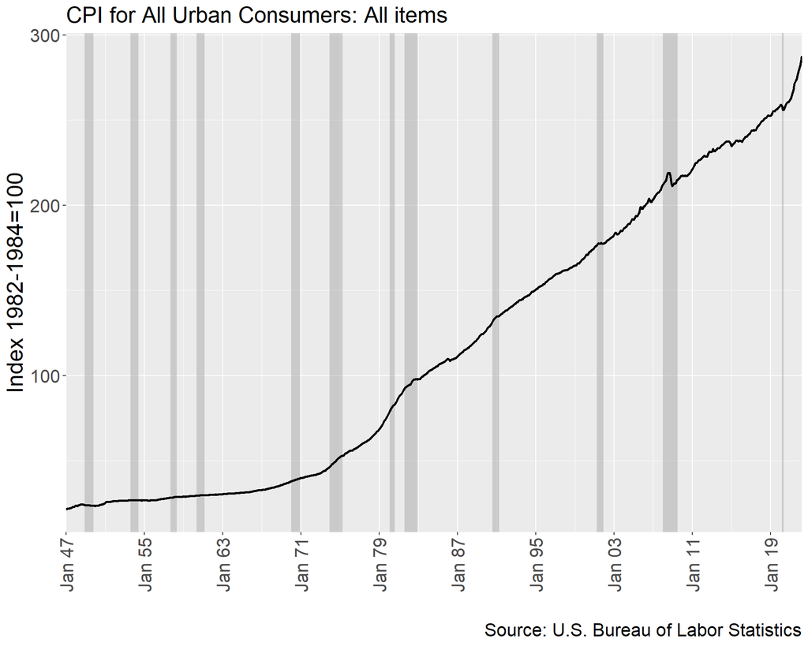

| Date | Period | Value |
| --- | --- | --- |
| 2021-06-01 | Jun 2021 | 270.955 |
| 2021-07-01 | Jul 2021 | 272.184 |
| 2021-08-01 | Aug 2021 | 273.092 |
| 2021-09-01 | Sep 2021 | 274.214 |
| 2021-10-01 | Okt 2021 | 276.590 |
| 2021-11-01 | Nov 2021 | 278.524 |
| 2021-12-01 | Dez 2021 | 280.126 |
| 2022-01-01 | Jan 2022 | 281.933 |
| 2022-02-01 | Feb 2022 | 284.182 |
| 2022-03-01 | Mrz 2022 | 287.708 |

```r
# Meta data
met.dat <- fredr_series_search_text("CPIAUCSL")
# Data
ser.dat <- fredr_series_observations(series_id=met.dat$id[1],
                                     observation_start=as.Date("1947-01-01"),
                                     units="lin")
# Transform date to yearmon class
ser.dat$date.zoo <- as.yearmon(ser.dat$date,"%y-%m-%d")
# Construct plot
cpi.01.plot <- ggplot(data=ser.dat,mapping=aes(x=date.zoo,y=value,color=series_id)) +
  add_rec_shade(min(ser.dat$date),max(ser.dat$date),zoo.mon=TRUE,zoo.qtr=FALSE) +
  geom_line(color = "black", size = 1) +
  scale_y_continuous(name="Index 1982-1984=100",labels=comma) +
  scale_x_yearmon(breaks=seq(from=min(ser.dat$date.zoo),to=max(ser.dat$date.zoo),by=8),
                  minor_breaks=seq(from=min(ser.dat$date.zoo),to=max(ser.dat$date.zoo),by=4),
                  format="%b %y",
                  expand = c(0, 0)) +
  labs(title = "CPI for All Urban Consumers: All items",
       caption = "Source: U.S. Bureau of Labor Statistics",
       x = "", y = "Index 1982-1984=100") +
  theme(legend.position="none",
        axis.text.x = element_text(angle=90, vjust = 0.5),
        text = element_text(size = 20),
        plot.title = element_text(size = 20))
# Print plot
cpi.01.plot
```

CPI (YoY percentage change)

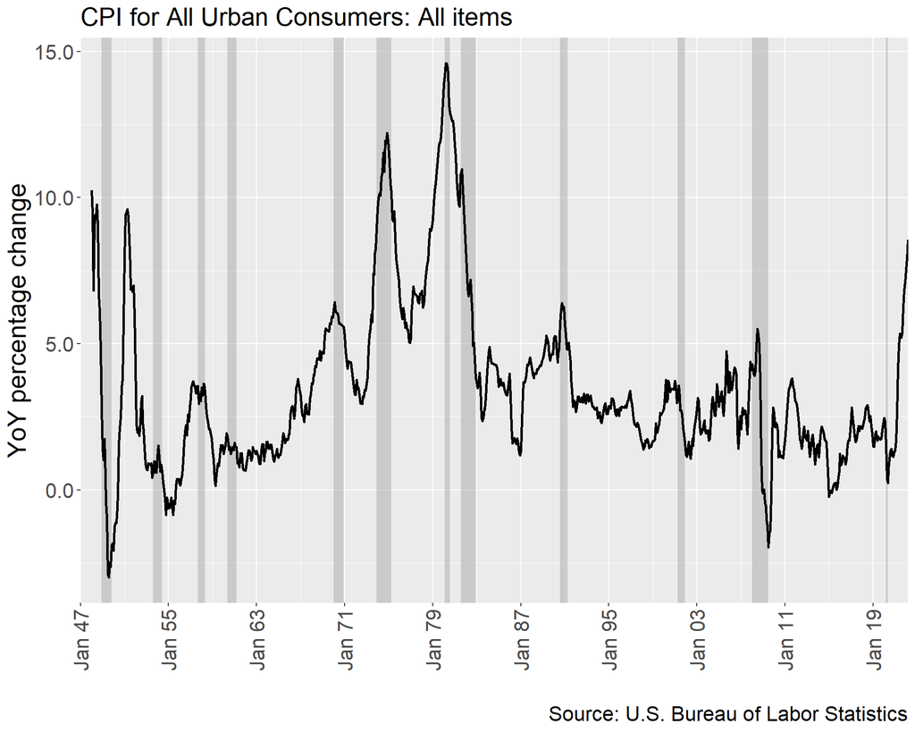

| Date | Period | Value |
| --- | --- | --- |
| 2021-06-01 | Jun 2021 | 5.34102 |
| 2021-07-01 | Jul 2021 | 5.27610 |
| 2021-08-01 | Aug 2021 | 5.20533 |
| 2021-09-01 | Sep 2021 | 5.38991 |
| 2021-10-01 | Okt 2021 | 6.23694 |
| 2021-11-01 | Nov 2021 | 6.82837 |
| 2021-12-01 | Dez 2021 | 7.09654 |
| 2022-01-01 | Jan 2022 | 7.52593 |
| 2022-02-01 | Feb 2022 | 7.91202 |
| 2022-03-01 | Mrz 2022 | 8.55759 |

```r
# Meta data
met.dat <- fredr_series_search_text("CPIAUCSL")
# Data
ser.dat <- fredr_series_observations(series_id=met.dat$id[1],
                                     observation_start=as.Date("1947-01-01"),
                                     units="pc1")
# Transform date to yearmon class
ser.dat$date.zoo <- as.yearmon(ser.dat$date,"%y-%m-%d")
# Construct plot
cpi.02.plot <- ggplot(data=ser.dat,mapping=aes(x=date.zoo,y=value,color=series_id)) +
  add_rec_shade(min(ser.dat$date),max(ser.dat$date),zoo.mon=TRUE,zoo.qtr=FALSE) +
  geom_line(color = "black", size = 1) +
  scale_y_continuous(name="YoY percentage change",labels=comma) +
  scale_x_yearmon(breaks=seq(from=min(ser.dat$date.zoo),to=max(ser.dat$date.zoo),by=8),
                  minor_breaks=seq(from=min(ser.dat$date.zoo),to=max(ser.dat$date.zoo),by=4),
                  format="%b %y",
                  expand = c(0, 0)) +
  labs(title = "CPI for All Urban Consumers: All items",
       caption = "Source: U.S. Bureau of Labor Statistics",
       x = "", y = "YoY percentage change") +
  theme(legend.position="none",
        axis.text.x = element_text(angle=90, vjust = 0.5),
        text = element_text(size = 20),
        plot.title = element_text(size = 20))
# Print plot
cpi.02.plot
```

CPI (MoM percentage change)

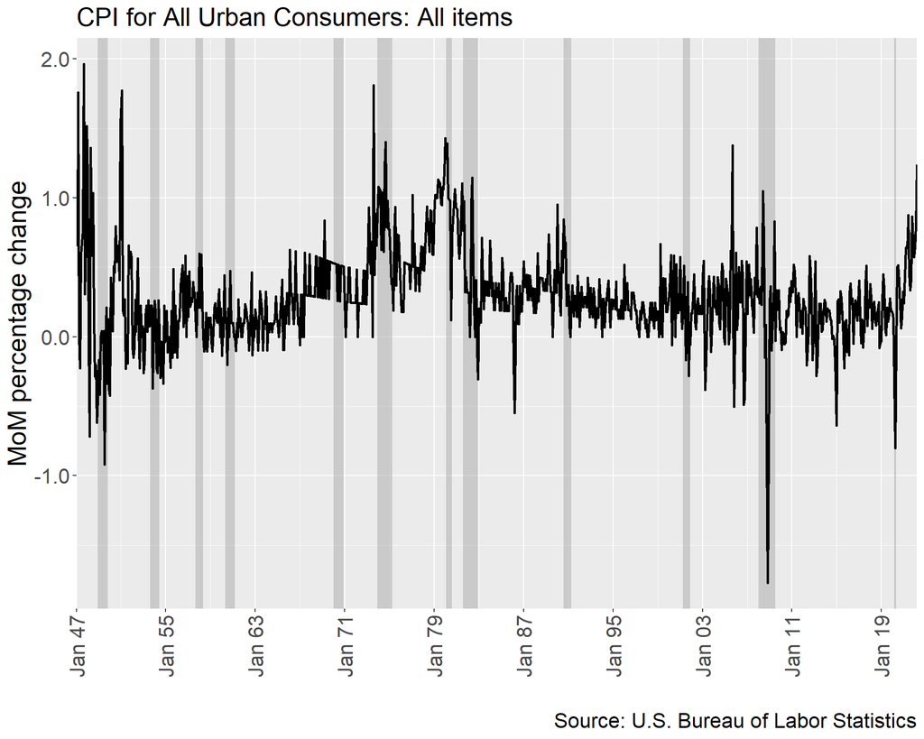

| Date | Period | Value |
| --- | --- | --- |
| 2021-06-01 | Jun 2021 | 0.87714 |
| 2021-07-01 | Jul 2021 | 0.45358 |
| 2021-08-01 | Aug 2021 | 0.33360 |
| 2021-09-01 | Sep 2021 | 0.41085 |
| 2021-10-01 | Okt 2021 | 0.86648 |
| 2021-11-01 | Nov 2021 | 0.69923 |
| 2021-12-01 | Dez 2021 | 0.57517 |
| 2022-01-01 | Jan 2022 | 0.64507 |
| 2022-02-01 | Feb 2022 | 0.79771 |
| 2022-03-01 | Mrz 2022 | 1.24075 |

```r
# Meta data
met.dat <- fredr_series_search_text("CPIAUCSL")
# Data
ser.dat <- fredr_series_observations(series_id=met.dat$id[1],
                                     observation_start=as.Date("1947-01-01"),
                                     units="pch")
# Transform date to yearmon class
ser.dat$date.zoo <- as.yearmon(ser.dat$date,"%y-%m-%d")
# Construct plot
cpi.03.plot <- ggplot(data=ser.dat,mapping=aes(x=date.zoo,y=value,color=series_id)) +
  add_rec_shade(min(ser.dat$date),max(ser.dat$date),zoo.mon=TRUE,zoo.qtr=FALSE) +
  geom_line(color = "black", size = 1) +
  scale_y_continuous(name="MoM percentage change",labels=comma) +
  scale_x_yearmon(breaks=seq(from=min(ser.dat$date.zoo),to=max(ser.dat$date.zoo),by=8),
                  minor_breaks=seq(from=min(ser.dat$date.zoo),to=max(ser.dat$date.zoo),by=4),
                  format="%b %y",
                  expand = c(0, 0)) +
  labs(title = "CPI for All Urban Consumers: All items",
       caption = "Source: U.S. Bureau of Labor Statistics",
       x = "", y = "MoM percentage change") +
  theme(legend.position="none",
        axis.text.x = element_text(angle=90, vjust = 0.5),
        text = element_text(size = 20),
        plot.title = element_text(size = 20))
# Print plot
cpi.03.plot
```

### Euro Area

Euro Area

HICP (YoY)

[figure not shown]

| Date | Period | GER | FRA | EA19 |
| --- | --- | --- | --- | --- |
| 2021-06-01 | Jun 2021 | 2.1 | 1.9 | 1.9 |
| 2021-07-01 | Jul 2021 | 3.1 | 1.5 | 2.2 |
| 2021-08-01 | Aug 2021 | 3.4 | 2.4 | 3.0 |
| 2021-09-01 | Sep 2021 | 4.1 | 2.7 | 3.4 |
| 2021-10-01 | Okt 2021 | 4.6 | 3.2 | 4.1 |
| 2021-11-01 | Nov 2021 | 6.0 | 3.4 | 4.9 |
| 2021-12-01 | Dez 2021 | 5.7 | 3.4 | 5.0 |
| 2022-01-01 | Jan 2022 | 5.1 | 3.3 | 5.1 |
| 2022-02-01 | Feb 2022 | 5.5 | 4.2 | 5.9 |
| 2022-03-01 | Mrz 2022 | 7.6 | 5.1 | NA |

```r
# Data
ser.dat <- get_eurostat(id="prc_hicp_manr",
                        filters=list(geo=c("DE","FR","EA19"),
                                     sinceTimePeriod=c("1997M01"),
                                     unit=c("RCH_A"),
                                     coicop=c("CP00")))
# Transform date to yearmon class
ser.dat$date.zoo <- as.yearmon(ser.dat$time,"%b%y")
# Construct plot
plot <- ggplot(data=ser.dat,mapping=aes(x=date.zoo,y=values,color=geo)) +
  geom_line(size = 1) +
  scale_y_continuous(name="Percent",labels=comma) +
  scale_x_yearmon(breaks=seq(from=min(ser.dat$date.zoo),to=max(ser.dat$date.zoo),by=2),
                  minor_breaks=seq(from=min(ser.dat$date.zoo),to=max(ser.dat$date.zoo),by=1),
                  format="%b %y",
                  expand = c(0, 0)) +
  scale_color_discrete(name = "", labels = c("GER","FRA","EA19")) +
  labs(title = "HICP (YoY Percentage Change)",
       caption = "Source: Eurostat",
       x = "", y = "Percent") +
  theme(legend.position="bottom",
        axis.text.x = element_text(angle=90, vjust = 0.5),
        text = element_text(size = 20))
# Print plot
plot
```

HICP (MoM)

[figure not shown]

| Date | Period | GER | FRA | EA19 |
| --- | --- | --- | --- | --- |
| 2021-06-01 | Jun 2021 | 0.4 | 0.2 | 0.3 |
| 2021-07-01 | Jul 2021 | 0.5 | 0.1 | -0.1 |
| 2021-08-01 | Aug 2021 | 0.1 | 0.7 | 0.4 |
| 2021-09-01 | Sep 2021 | 0.3 | -0.2 | 0.5 |
| 2021-10-01 | Okt 2021 | 0.5 | 0.4 | 0.8 |
| 2021-11-01 | Nov 2021 | 0.3 | 0.4 | 0.4 |
| 2021-12-01 | Dez 2021 | 0.3 | 0.2 | 0.4 |
| 2022-01-01 | Jan 2022 | 0.9 | 0.2 | 0.3 |
| 2022-02-01 | Feb 2022 | 0.9 | 0.9 | 0.9 |
| 2022-03-01 | Mrz 2022 | 2.5 | 1.6 | NA |

```r
# Data
ser.dat <- get_eurostat(id="prc_hicp_mmor",
                        filters=list(geo=c("DE","FR","EA19"),
                                     sinceTimePeriod=c("1997M01"),
                                     unit=c("RCH_M"),
                                     coicop=c("CP00")))
# Transform date to yearmon class
ser.dat$date.zoo <- as.yearmon(ser.dat$time,"%b%y")
# Construct plot
plot <- ggplot(data=ser.dat,mapping=aes(x=date.zoo,y=values,color=geo)) +
  geom_line(size = 1) +
  scale_y_continuous(name="Percent",labels=comma) +
  scale_x_yearmon(breaks=seq(from=min(ser.dat$date.zoo),to=max(ser.dat$date.zoo),by=2),
                  minor_breaks=seq(from=min(ser.dat$date.zoo),to=max(ser.dat$date.zoo),by=1),
                  format="%b %y",
                  expand = c(0, 0)) +
  scale_color_discrete(name = "", labels = c("GER","FRA","EA19")) +
  labs(title = "HICP (MoM Percentage Change)",
       caption = "Source: Eurostat",
       x = "", y = "Percent") +
  theme(legend.position="bottom",
        axis.text.x = element_text(angle=90, vjust = 0.5),
        text = element_text(size = 20))
# Print plot
plot
```

## Zinssätze

Zinssätze

### USA

USA

Staatsanleihen (konstante Laufzeit)

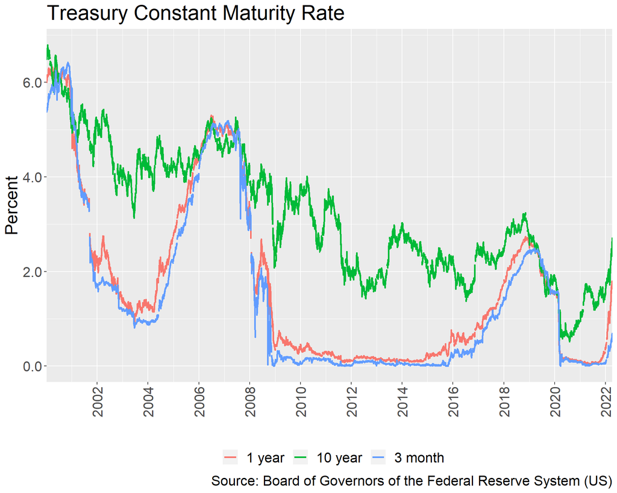

| Date | 3 M | 1 Y | 10 Y |
| --- | --- | --- | --- |
| 2022-02-28 | 0.35 | 1.01 | 1.83 |
| 2022-03-01 | 0.32 | 0.91 | 1.72 |
| 2022-03-02 | 0.34 | 1.06 | 1.86 |
| 2022-03-03 | 0.38 | 1.08 | 1.86 |
| 2022-03-04 | 0.34 | 1.05 | 1.74 |
| 2022-03-07 | 0.38 | 1.07 | 1.78 |
| 2022-03-08 | 0.36 | 1.12 | 1.86 |
| 2022-03-09 | 0.38 | 1.15 | 1.94 |
| 2022-03-10 | 0.39 | 1.19 | 1.98 |
| 2022-03-11 | 0.40 | 1.22 | 2.00 |
| 2022-03-14 | 0.45 | 1.28 | 2.14 |
| 2022-03-15 | 0.46 | 1.28 | 2.15 |
| 2022-03-16 | 0.44 | 1.35 | 2.19 |
| 2022-03-17 | 0.40 | 1.30 | 2.20 |
| 2022-03-18 | 0.42 | 1.29 | 2.14 |
| 2022-03-21 | 0.54 | 1.40 | 2.32 |
| 2022-03-22 | 0.51 | 1.59 | 2.38 |
| 2022-03-23 | 0.50 | 1.52 | 2.32 |
| 2022-03-24 | 0.52 | 1.55 | 2.34 |
| 2022-03-25 | 0.55 | 1.67 | 2.48 |
| 2022-03-28 | 0.59 | 1.69 | 2.46 |
| 2022-03-29 | 0.55 | 1.67 | 2.41 |
| 2022-03-30 | 0.55 | 1.64 | 2.35 |
| 2022-03-31 | 0.52 | 1.63 | 2.32 |
| 2022-04-01 | 0.53 | 1.72 | 2.39 |
| 2022-04-04 | 0.66 | 1.72 | 2.42 |
| 2022-04-05 | 0.65 | 1.77 | 2.54 |
| 2022-04-06 | 0.67 | 1.79 | 2.61 |
| 2022-04-07 | 0.68 | 1.78 | 2.66 |
| 2022-04-08 | 0.70 | 1.81 | 2.72 |

```r
# Time series IDs
id.lis <- list(m03="DGS3MO",y01="DGS1",y10="DGS10")
# Meta data
met.lis <- lapply(id.lis,
                  fredr_series_search_text)
# Data
ser.lis <- lapply(id.lis,
                  fredr_series_observations,
                  observation_start=as.Date("2000-01-01"),
                  observation_end=as.Date(Sys.Date()),
                  units="lin")
ser.dat <- rbind(ser.lis$m03,ser.lis$y01,ser.lis$y10)
# Construct plot
tre.con.mat.plot <- ggplot(data=ser.dat,mapping=aes(x=date,y=value,color=series_id)) +
  geom_line(size = 1) +
  scale_y_continuous(name="Percent",labels=comma) +
  scale_x_date(date_breaks = "2 years",
               date_minor_breaks = "1 years",
               date_labels = "%Y",
               expand = c(0, 0)) +
  scale_color_discrete(name = "", labels = c("1 year", "10 year", "3 month")) +
  labs(title = "Treasury Constant Maturity Rate",
       caption = "Source: Board of Governors of the Federal Reserve System (US)",
       x = "", y = "Percent") +
  theme(legend.position="bottom",
        axis.text.x = element_text(angle=90, vjust = 0.5),
        text = element_text(size = 20))
# Print plot
tre.con.mat.plot
```

Federal Funds Rate (Upper Limit)

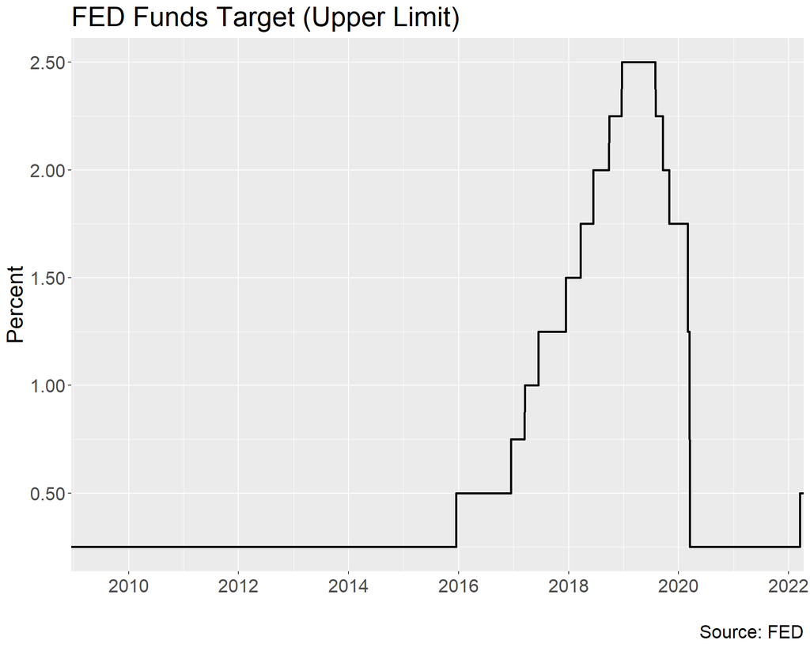

| Date | Value |
| --- | --- |
| 2022-04-02 | 0.5 |
| 2022-04-03 | 0.5 |
| 2022-04-04 | 0.5 |
| 2022-04-05 | 0.5 |
| 2022-04-06 | 0.5 |
| 2022-04-07 | 0.5 |
| 2022-04-08 | 0.5 |
| 2022-04-09 | 0.5 |
| 2022-04-10 | 0.5 |
| 2022-04-11 | 0.5 |

```r
# Meta data
met.dat <- fredr_series_search_text("DFEDTARU")
# Data
ffr.dat <- fredr_series_observations(series_id=met.dat$id[1],
                                     observation_start=as.Date("1999-12-31"),
                                     units="lin")
# Construct plot
pol.rat.plot <- ggplot(data=ffr.dat,mapping=aes(x=date,y=value)) +
  geom_line(size = 1) +
  scale_y_continuous(name="Percent",labels=comma) +
  scale_x_date(date_breaks = "2 years",
               date_minor_breaks = "1 years",
               date_labels = "%Y",
               expand = c(0, 0)) +
  labs(title = "FED Funds Target (Upper Limit)",
       caption = "Source: FED",
       x = "", y = "Percent") +
  theme(legend.position="bottom",
        axis.text.x = element_text(vjust = 0.5),
        text = element_text(size = 20))
# Print plot
pol.rat.plot
```

### Euro Area

Euro Area

Yield Curve

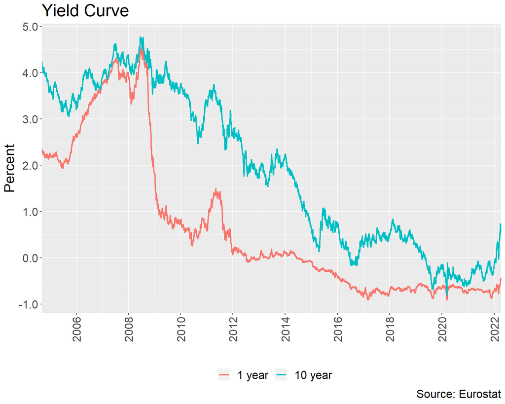

| Date | 01Y | 10Y |
| --- | --- | --- |
| 2022-02-25 | -0.62359 | 0.26437 |
| 2022-02-28 | -0.68159 | 0.21519 |
| 2022-03-01 | -0.76325 | 0.03267 |
| 2022-03-02 | -0.72162 | 0.03138 |
| 2022-03-03 | -0.69124 | 0.09868 |
| 2022-03-04 | -0.77383 | -0.02795 |
| 2022-03-07 | -0.75079 | 0.02574 |
| 2022-03-08 | -0.71564 | 0.15544 |
| 2022-03-10 | -0.64777 | 0.28647 |
| 2022-03-11 | -0.61535 | 0.30924 |
| 2022-03-14 | -0.60156 | 0.37665 |
| 2022-03-15 | -0.62767 | 0.37341 |
| 2022-03-16 | -0.62008 | 0.41485 |
| 2022-03-17 | -0.62542 | 0.41715 |
| 2022-03-18 | -0.63440 | 0.39875 |
| 2022-03-21 | -0.60141 | 0.47004 |
| 2022-03-22 | -0.57930 | 0.53771 |
| 2022-03-23 | -0.58914 | 0.51602 |
| 2022-03-24 | -0.58008 | 0.54126 |
| 2022-03-25 | -0.56129 | 0.59553 |
| 2022-03-28 | -0.54738 | 0.59712 |
| 2022-03-29 | -0.48497 | 0.62662 |
| 2022-03-30 | -0.45627 | 0.72626 |
| 2022-03-31 | -0.49411 | 0.61786 |
| 2022-04-01 | -0.48379 | 0.63764 |
| 2022-04-04 | -0.48691 | 0.56382 |
| 2022-04-05 | -0.47330 | 0.63270 |
| 2022-04-06 | -0.46282 | 0.71407 |
| 2022-04-07 | -0.45065 | 0.74096 |
| 2022-04-08 | -0.44175 | 0.74240 |

```r
# Data
ser.dat <- get_eurostat(id="irt_euryld_d",
                        filters=list(sinceTimePeriod=c("2004M09D06"),
                                     maturity=c("Y1","Y10"),
                                     bonds=c("CGB_EA_AAA"),
                                     yld_curv=c("SPOT_RT")))
# Construct plot
plot <- ggplot(data=ser.dat,mapping=aes(x=time,y=values,color=maturity)) +
  geom_line(size = 1) +
  scale_y_continuous(name="Percent",labels=comma) +
  scale_x_date(date_breaks = "2 years",
               date_minor_breaks = "1 years",
               date_labels = "%Y",
               expand = c(0, 0)) +
  scale_color_discrete(name = "", labels = c("1 year", "10 year")) +
  labs(title = "Yield Curve",
       caption = "Source: Eurostat",
       x = "", y = "Percent") +
  theme(legend.position="bottom",
        axis.text.x = element_text(angle=90, vjust = 0.5),
        text = element_text(size = 20))
# Print plot
plot
```

Main Refinancing Operation (MRO) rate

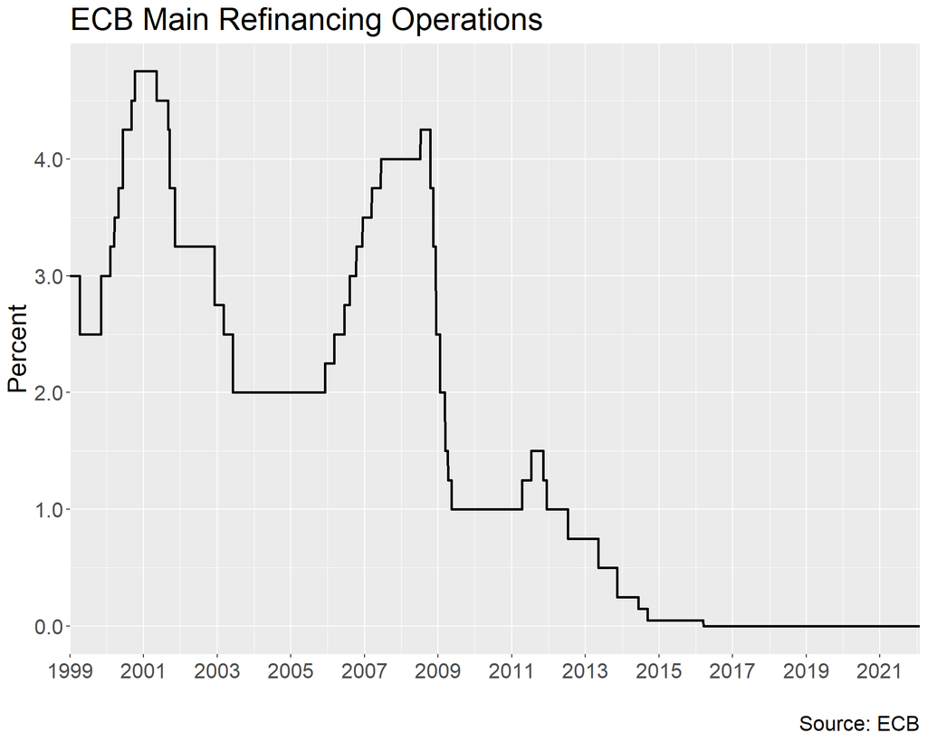

|  | Date | Value |
| --- | --- | --- |
| 8423 | 2022-01-22 | 0 |
| 8424 | 2022-01-23 | 0 |
| 8425 | 2022-01-24 | 0 |
| 8426 | 2022-01-25 | 0 |
| 8427 | 2022-01-26 | 0 |
| 8428 | 2022-01-27 | 0 |
| 8429 | 2022-01-28 | 0 |
| 8430 | 2022-01-29 | 0 |
| 8431 | 2022-01-30 | 0 |
| 8432 | 2022-01-31 | 0 |

```r
# Main refinancing operations (fixed rate)
filter <- list(startPeriod = 1999-01-01,
               endPeriod = 2022-01-01)
key <- "FM.B.U2.EUR.4F.KR.MRR_FR.LEV"
dat.01 <- get_data(key, filter)
dat.01$date <- as.Date(dat.01$obstime)
colnames(dat.01)[9] <- c("mro.01.00")
# Main refinancing operations (minimun bid rate)
filter <- list(startPeriod = 1999-01-01,
               endPeriod = 2022-01-01)
key <- "FM.B.U2.EUR.4F.KR.MRR_MBR.LEV"
dat.02 <- get_data(key, filter)
dat.02$date <- as.Date(dat.02$obstime)
colnames(dat.02)[9] <- c("mro.02.00")

# head(dat.01$date) # only changes are recorded

date.df <- data.frame(date=seq(as.Date("1999-01-01"), as.Date("2022-01-31"), by="day"))

# insert all dates for fixed rate
dat.03 <- merge(date.df,dat.01,by="date",all.x = TRUE)
dat.03$mro.01[1] <- dat.03$mro.01.00[1]
for (ii in 2:nrow(dat.03)) {
  if (is.na(dat.03$mro.01.00[ii])) {
    dat.03$mro.01[ii] <- dat.03$mro.01[ii-1]
  } else {
    dat.03$mro.01[ii] <- dat.03$mro.01.00[ii]
  }
}

# insert all dates for minimum bid rate
dat.04 <- merge(date.df,dat.02,by="date",all.x = TRUE)
dat.04$mro.02[1] <- dat.04$mro.02.00[1]
for (ii in 2:nrow(dat.04)) {
  if (is.na(dat.04$mro.02.00[ii])) {
    dat.04$mro.02[ii] <- dat.04$mro.02[ii-1]
  } else {
    dat.04$mro.02[ii] <- dat.04$mro.02.00[ii]
  }
}

# mro as combination of fixed rate and minimum bid rate
dat.05 <- data.frame(date=dat.03$date,
                     mro=ifelse(dat.03$date %in% seq(as.Date("2000-06-28"), as.Date("2008-10-15"), by="day"),dat.04$mro.02,dat.03$mro.01))

# Construct plot
plt <- ggplot(data=dat.05,mapping=aes(x=date,y=mro)) +
  geom_line(size = 1) +
  scale_y_continuous(name="Percent",labels=comma) +
  scale_x_date(date_breaks = "2 years",
               date_minor_breaks = "1 years",
               date_labels = "%Y",
               expand = c(0, 0)) +
  labs(title = "ECB Main Refinancing Operations",
       caption = "Source: ECB",
       x = "", y = "Percent") +
  theme(legend.position="bottom",
        axis.text.x = element_text(vjust = 0.5),
        text = element_text(size = 20))
# Print plot
plt
```

## Wechselkurse

Wechselkurse

### USA

EUR/USD

EUR/USD Wechselkurs

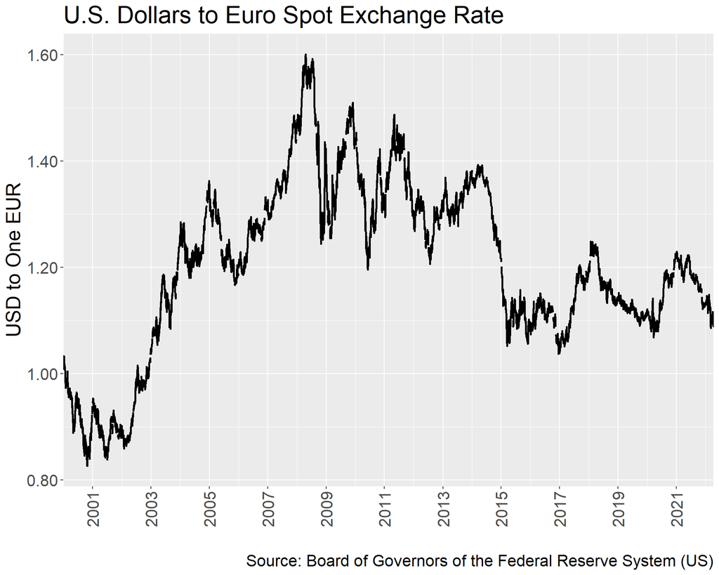

| Date | Value |
| --- | --- |
| 2022-02-28 | 1.1224 |
| 2022-03-01 | 1.1103 |
| 2022-03-02 | 1.1102 |
| 2022-03-03 | 1.1053 |
| 2022-03-04 | 1.0912 |
| 2022-03-07 | 1.0860 |
| 2022-03-08 | 1.0881 |
| 2022-03-09 | 1.1069 |
| 2022-03-10 | 1.1007 |
| 2022-03-11 | 1.0937 |
| 2022-03-14 | 1.0979 |
| 2022-03-15 | 1.0974 |
| 2022-03-16 | 1.0996 |
| 2022-03-17 | 1.1110 |
| 2022-03-18 | 1.1044 |
| 2022-03-21 | 1.1048 |
| 2022-03-22 | 1.1022 |
| 2022-03-23 | 1.1001 |
| 2022-03-24 | 1.1006 |
| 2022-03-25 | 1.0985 |
| 2022-03-28 | 1.0977 |
| 2022-03-29 | 1.1104 |
| 2022-03-30 | 1.1163 |
| 2022-03-31 | 1.1093 |
| 2022-04-01 | 1.1043 |
| 2022-04-04 | 1.0992 |
| 2022-04-05 | 1.0921 |
| 2022-04-06 | 1.0913 |
| 2022-04-07 | 1.0900 |
| 2022-04-08 | 1.0874 |

```r
# Meta data
met.dat <- fredr_series_search_text("DEXUSEU")
# Data
ser.dat <- fredr_series_observations(series_id=met.dat$id[1],
                                     observation_start=as.Date("1999-12-31"),
                                     units="lin")
# Construct plot
fx.eur.usd.plot <- ggplot(data=ser.dat,mapping=aes(x=date,y=value,color=series_id)) +
  geom_line(color = "black", size = 1) +
  scale_y_continuous(name="USD to One EUR",labels=comma) +
  scale_x_date(date_breaks = "2 years",
               date_minor_breaks = "1 years",
               date_labels = "%Y",
               expand = c(0, 0)) +
  labs(title = paste(met.dat$title[1]),
       caption = "Source: Board of Governors of the Federal Reserve System (US)",
       x = "", y = "USD to One EUR") +
  theme(legend.position="none",
        axis.text.x = element_text(angle=90, vjust = 0.5),
        text = element_text(size = 20))
# Print plot
fx.eur.usd.plot
```

USD/SFR

USD/SFR Wechselkurs

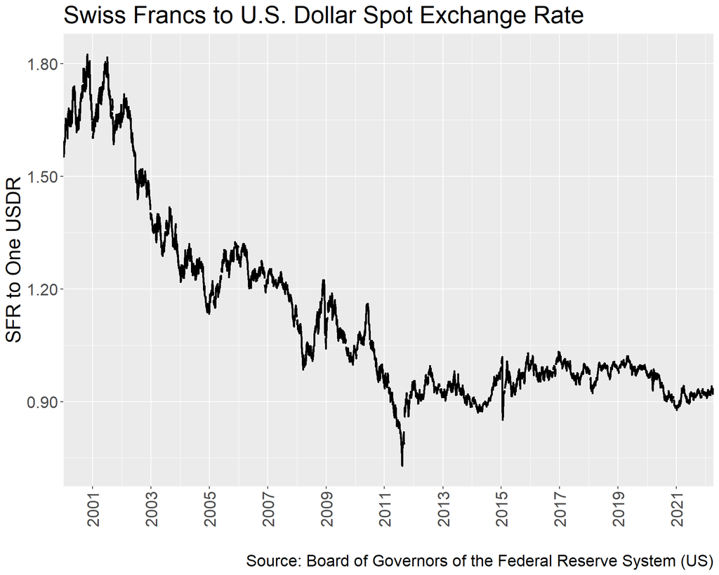

| Date | Value |
| --- | --- |
| 2022-02-28 | 0.9179 |
| 2022-03-01 | 0.9186 |
| 2022-03-02 | 0.9216 |
| 2022-03-03 | 0.9204 |
| 2022-03-04 | 0.9183 |
| 2022-03-07 | 0.9267 |
| 2022-03-08 | 0.9302 |
| 2022-03-09 | 0.9264 |
| 2022-03-10 | 0.9294 |
| 2022-03-11 | 0.9326 |
| 2022-03-14 | 0.9358 |
| 2022-03-15 | 0.9415 |
| 2022-03-16 | 0.9414 |
| 2022-03-17 | 0.9349 |
| 2022-03-18 | 0.9337 |
| 2022-03-21 | 0.9303 |
| 2022-03-22 | 0.9325 |
| 2022-03-23 | 0.9318 |
| 2022-03-24 | 0.9308 |
| 2022-03-25 | 0.9308 |
| 2022-03-28 | 0.9344 |
| 2022-03-29 | 0.9303 |
| 2022-03-30 | 0.9233 |
| 2022-03-31 | 0.9211 |
| 2022-04-01 | 0.9256 |
| 2022-04-04 | 0.9256 |
| 2022-04-05 | 0.9292 |
| 2022-04-06 | 0.9325 |
| 2022-04-07 | 0.9332 |
| 2022-04-08 | 0.9333 |

```r
# Meta data
met.dat <- fredr_series_search_text("DEXSZUS")
# Data
ser.dat <- fredr_series_observations(series_id=met.dat$id[1],
                                     observation_start=as.Date("1999-12-31"),
                                     units="lin")
# Construct plot
fx.usd.sfr.plot <- ggplot(data=ser.dat,mapping=aes(x=date,y=value,color=series_id)) +
  geom_line(color = "black", size = 1) +
  scale_y_continuous(name="SFR to One USDR",labels=comma) +
  scale_x_date(date_breaks = "2 years",
               date_minor_breaks = "1 years",
               date_labels = "%Y",
               expand = c(0, 0)) +
  labs(title = paste(met.dat$title[1]),
       caption = "Source: Board of Governors of the Federal Reserve System (US)",
       x = "", y = "SFR to One USDR") +
  theme(legend.position="none",
        axis.text.x = element_text(angle=90, vjust = 0.5),
        text = element_text(size = 20))
# Print plot
fx.usd.sfr.plot
```